# Preservation, Redevelopment, and Housing Stability in Boston: A User’s Guide to the Preservation Ratio

Samuel Nukporfe

December 10, 2024

## Overview

This project grew out of a semester spent learning how data can illuminate the lived experiences of communities, particularly those along the Blue Hill Avenue corridor, where neighborhood identity, stability, and belonging have been shaped by decades of structural inequity, disinvestment, and displacement pressure. During workshops with the Dudley Street Neighborhood Initiative, community partners repeatedly emphasized a concern that development in their neighborhoods is not simply about the number of new buildings appearing on a block, but about who benefits from that development and who is displaced by it. Raising these concerns prompted me to think less about the quantity of investment and more about the quality and orientation of that investment, whether it supports existing residents or transforms neighborhoods in ways that push them out.

This community framing inspired the development of a metric that captures a simple but powerful question: When money flows into Boston’s neighborhoods, does it strengthen the homes and buildings that people already rely on, or does it replace them? The Preservation Ratio, created entirely from the City of Boston’s building permits dataset, quantifies the share of total investment allocated to renovating existing structures rather than replacing them through new construction, additions, or demolitions. Applied to 2,146 census blocks in Boston’s 2024 building activity, the measure reveals geographic patterns in development orientation and demonstrates that ownership structure, rather than demographics, predicts whether neighborhoods experience preservation-focused or redevelopment-focused investment.

However, field observations and community testimony revealed critical limitations in what this metric captures. High preservation ratios do not guarantee community benefit; renovation can facilitate displacement through rent increases and property flipping as effectively as demolition driven redevelopment. This report provides a complete guide to understanding how the Preservation Ratio was constructed, what it reveals about Boston’s development patterns, and how it might be used by residents, practitioners, and policymakers as one tool among many for tracking neighborhood change, while acknowledging that numbers alone cannot capture whether development strengthens or threatens community stability.

## User’s Guide to a Community-Inspired Metric

### What is the community-based process that inspired your measure?

The Preservation Ratio emerged directly from conversations during workshops with DSNI and the broader Blue Hill Avenue community partners. These were not abstract academic discussions, they were grounded in residents’ lived experiences of neighborhood change.

Community members repeatedly described a specific pattern: buildings they had lived near for decades were being purchased, demolished, and replaced with market rate housing. While these projects brought visible investment activity and increased property values, they did not benefit existing residents who could not afford the new units. In contrast, when property owners renovated existing buildings such as fixing roofs, updating facades, making necessary repairs, those structures typically remained more accessible and affordable to current residents.

This distinction was not something I imposed on the data; it came directly from community voices. DSNI member voiced out these concerns and I needed tools to distinguish between:

**Investment that works with their community** : This describes the capital that repairs and maintains the physical fabric of the neighborhood in a way that supports current residents. This includes essential renovations like fixing a leaky roof, rehabilitating a worn-out building system, or making modest improvements that allow people to remain safely and comfortably in their homes. This type of investment strengthens existing community ties and reinforces a sense of belonging and stability and by contrast

**Investment that works against their community** : This is the capital that physically transforms or replaces the neighborhood in ways that exclude current residents. This primarily manifests as the demolition of existing, often more affordable housing and its replacement with new, high end luxury construction. The result is not maintenance but replacement, a process that inherently prices out the people who called that place home. This investment works against the community by severing connections, displacing families, and altering the neighborhood’s character and accessibility. The distinction between these two flows of capital is not just about construction type, but about fundamental alignment: does this money help the people already here stay, or does it fund a neighborhood for someone else?

At the same time, the building permit data we were analyzing for this course recorded exactly these types of work: renovations, additions, demolitions, and new construction, along with the declared monetary value of each project. This made it possible to operationalize the community’s conceptual distinction using quantitative data.

The metric’s development involved iterative refinement based on community feedback. Initial proposals simply counted project types (renovation vs. new construction), but community members noted that one expensive new construction project could transform a neighborhood more than dozens of small roof repairs. This led to the dollar weighted version (renovation investment / total investment) as the primary measure. Every methodological decision from focusing on 2024 data to excluding government projects was shaped by community input about what would make the metric most useful for understanding development pressure.

### What does it reveal about Boston?

#### Understanding the Preservation Ratio

The Preservation Ratio is a measure that describes the share of total investment in a neighborhood allocated to renovating existing structures rather than replacing them through new construction, additions, or demolitions. It is calculated as:

$$\text{Preservation Ratio} =
\frac{\text{Renovation Investment}}{\text{Total
Investment}}$$

Where:

**Renovation Investment** = sum of declared valuations for all permits flagged as renovations (`reno = 1`)

**Total Investment** = sum of declared valuations for all building permits (new construction + renovation + addition + demolition)

The ratio ranges from 0 to 1, where values near 1.0 indicate renovation focused investment and values near 0 indicate redevelopment-focused investment.

From a community standpoint, the Preservation Ratio reveals something essential about the orientation of development. A high ratio suggests a pattern of reinvesting in what already exists, work that can stabilize families and maintain neighborhood identity. A low ratio indicates a shift toward redevelopment that often brings displacement pressure. Blue Hill Avenue residents articulated this distinction clearly, and the metric was designed to allow them to track it in their own neighborhoods.

#### The Project Dollar Gap: What Boston’s 2024 Data Shows

Applying the Preservation Ratio to Boston’s 2024 building activity revealed a striking pattern: while renovation is extremely common at the project level, investment dollars flow disproportionately toward redevelopment in many parts of the city.

Applying the Preservation Ratio to Boston’s 2024 building activity revealed a striking pattern: while renovation is extremely common at the project level, investment dollars flow disproportionately toward redevelopment in many parts of the city.Across the 2,146 census blocks we analyzed, 92% of all construction projects were renovations, but only 49% of total investment dollars went toward that work.

This reveals a fundamental disconnect between the physical activity in neighborhoods and the flow of development capital. By simply counting construction sites, Boston appears to be a renovation heavy city, the visible work predominantly involves fixing and updating existing structures. But when we follow the money, a different story emerges. Large financial flows favor redevelopment, where a few expensive new construction and major addition projects consume investment dollars that are completely disproportionate to how frequently they occur.

This imbalance speaks directly to the concerns raised by community members who observe that while there might be many small projects happening around them, it is often the one or two large developments that truly reshape a block, alter the character of a street, and introduce displacement pressure even when those small renovation projects numerically dominate the landscape.

#### Where Preservation and Redevelopment Concentrate

To ensure I was working with reliable data, my analysis focused on census blocks with enough development activity to produce meaningful ratios. This meant examining 2,146 census blocks that had three or more building projects in 2024. I excluded 3,829 additional blocks from the analysis because they had insufficient construction activity , either fewer than three projects or no permitted work at all which would have made their preservation ratios unstable and misleading.

**Downtown, Seaport, and waterfront** show concentrated redevelopment (low preservation)

**Residential neighborhoods** in Dorchester, Roxbury, Mattapan maintain higher preservation

**Blue Hill Avenue corridor** shows predominantly high preservation

#### The Blue Hill Avenue Pattern: An Exception Requiring Careful Interpretation

At first glance, the statistical story of Blue Hill Avenue seemed surprisingly ordinary. Initial tests comparing the corridor to the rest of Boston revealed no significant difference in their development patterns. Blue Hill Avenue tracts showed a mean preservation ratio of 74.8%, while other Boston neighborhoods averaged 76.6%. This minute difference was not statistically meaningful (t = -0.63, p = 0.53), meaning that in a simple geographic comparison, Blue Hill Avenue looked essentially the same as the rest of the city. This pattern held when we examined other potential drivers. Neighborhoods with different racial compositions showed no significant variation in their preservation ratios, and income level alone also failed to predict whether a neighborhood would experience preservation-focused or redevelopment-focused investment. These initial null findings were revealing, they told us that the story of development in Boston was not simply about where a neighborhood was located, who lived there, or how much they earned. A more complex mechanism was at work, pushing us to look beyond demographics and toward the structure of ownership and investment itself.

However, when we moved beyond simple comparisons and used multivariate regression to account for multiple factors simultaneously, a much more complex and revealing story about Blue Hill Avenue emerged. The analysis uncovered a striking divergence in how the corridor responds to corporate ownership compared to the rest of the city.

**Citywide**: the relationship is clear and negative: more corporate ownership predicts less preservation. For each percentage point increase in corporate-owned properties in a tract, the preservation ratio decreases by about 0.33 percentage points (β = -0.329, p < 0.001). This aligns with the common narrative that outside corporate investment tends to drive redevelopment, however, on

**Blue Hill Avenue**: the corporate ownership correlates with higher preservation. The statistical interaction term which captures how Blue Hill’s response differs from the city norm. it is strongly positive and significant (β = 0.926, p < 0.05). In practical terms, this means that while a 10% increase in corporate ownership might lower preservation by about 3.3 points elsewhere in Boston, the same increase on Blue Hill is associated with preservation rising by roughly 5.9 points.

This counter intuitive pattern demands careful interpretation. It could signal several underlying realities working in tandem: it may reflect the success of community organizing in constraining demolition; it could indicate that market conditions make renovation more profitable than new construction in the corridor; or it might represent a mix of mechanisms where community development corporations preserve affordability while speculative investors pursue a “renovate-to-displace” model. Critically, reports from DSNI members of ongoing displacement pressure confirm that high preservation ratios do not necessarily mean community stability, this statistical pattern can, and does, coexist with economic transformation that pushes residents out

### How do you think it could be informative or useful to community members?

The Preservation Ratio offers community organizations a simple, replicable method for monitoring neighborhood development pressure.

#### Practical Applications

**Application 1: Early Warning System**

Communities can calculate preservation ratios annually to identify development shifts. A neighborhood maintaining 75-80% preservation that drops to 50-60% signals increasing displacement pressure.

*How to use*: DSNI and other community organaizations could track Blue Hill Avenue’s ratio annually. If corporate ownership increases AND preservation drops, this warns the current pattern may be weakening.Howver, there is a limitation, that is, high ratios may coexist with displacement if renovations serve luxury markets.

**Application 2: Spatial Targeting**

Mapping ratios highlights where redevelopment concentrates. Communities can prioritize blocks for organizing, identify where zoning interventions are needed, and document displacement risk.

*How to use*: Overlay preservation maps with property sales to identify hot spots for community land trust acquisition.This is approach is also limited as the map show where development occure and not why they occurs.

**Application 3: Evidence for Advocacy**

The metric provides quantitative backing for policy conversations. Communities can show whether their neighborhood differs from citywide patterns and whether policies encourage preservation.

*How to use*: DSNI and other organizations could show Blue Hill maintains higher preservation than other high corporate areas, supporting policies that ensure renovations serve existing residents however, we should be careful as these patters do not establish causation.

**Application 4: Distinguishing Type from Impact**

Communities can demonstrate that where money flows does not determine who benefits. High preservation may coexist with displacement.

*How to use*: If residents report pressure despite high preservation, argue for policies addressing renovation driven displacement (rent stabilization, anti flipping), not just demolition. This approach does not measure displacement directly

#### What the Metric Cannot Measure

**Renovation purpose is invisible**: One of the most important limitations of the Preservation Ratio is that building permit data cannot tell us why a renovation is happening. The same dollar amount spent on a building could represent a longtime homeowner fixing their roof to stay in their home, or it could be an investor doing a luxury upgrade to flip the property for profit. Both would appear identical in our metric, both count as “renovation investment” but they have completely opposite effects on community stability. This means a neighborhood with high preservation ratios might actually be experiencing intense speculation and turnover, not stability. Without understanding who is doing the renovation and why, the metric can sometimes give a misleading signal about what’s actually happening on the ground.

**Scale and density hidden**: The Preservation Ratio treats all investment dollars equally, but dollars can do very different things depending on what they are spent on. For example, a $2 million renovation of a 4 unit building and a $2 million new construction of a 20-unit building would both appear as $2 million in our calculations. The renovation would contribute to a high preservation ratio, while the new construction would lower it. But the new construction actually adds 16 more housing units to the neighborhood, while the renovation does not change the housing supply at all. This means the metric is “blind to density” as it cannot tell us whether development is increasing housing supply, which is crucial for addressing housing shortages. A neighborhood could have high preservation ratios while actually losing housing units if renovations consolidate apartments into fewer, larger units.

**Ownership and tenant outcomes missing**: While we can identify corporate ownership from permit data, we cannot see what happens to tenants or track property turnover over time. The data does not tell us whether a renovated building saw rent increases, whether existing tenants were displaced, or whether the property changed hands. Even more importantly, we can npt distinguish between different types of corporate owners. A community development corporation preserving affordable housing looks exactly the same in our data as a speculative investor flipping properties. This is a critical gap because the same renovation done by a nonprofit CDC and done by a for profit speculator have opposite effects on community stability. Without tenant outcome data, we are measuring the container but not what is inside it.

**Temporal gaps**: Building permits only capture the moment when construction begins, not the longer story of what happened to a property beforehand. A building that sat vacant for five years before being renovated appears in our data only when the renovation permit is issued. That five year period of vacancy and disinvestment which often destabilizes a block and lowers property values is completely invisible in our analysis. Similarly, we cannot see properties that are being “warehoused”, bought and left empty in anticipation of future development. This means our snapshot of 2024 activity might miss important pre-development pressures that communities are already feeling. The metric shows us what’s happening now, but not how we got here or what might be coming next.

#### Recommendations

1. Use as one tool among many
2. Combine with tenant testimony
3. Monitor alongside rent data, evictions, demographics
4. Track corporate ownership separately
5. Generate organizing questions, not definitive answers

## Measurement Construction

This section summarizes the exact transformations applied to the Boston building permits dataset to create the Preservation Ratio and all supporting variables.

### Record-Level Information Used

From the original building permits dataset (691,985 records covering 2006-2024), I relied on:

**Permit type flags**: `newcon`, `reno`, `addition`, `demo` : Binary indicators showing whether each permit involves new construction, renovation, addition to existing structure, or demolition

**Declared valuation**: `DECLARED_VALUATION` : Monetary estimate for each permit in dollars

**Parcel identifier**: `Land_Parcel_ID` : Groups all permits belonging to one physical project

**Census block ID**: `Blk_ID_20` : 2020 Census block identifier (15-digit GEOID)

**Owner name**: `owner` : Used to classify corporate vs. individual ownership

**Issue date**: `ISSUED_DATE` : Used to filter data to 2024

These variables capture the foundational elements needed to distinguish preservation-oriented investment from redevelopment-oriented investment.

### Constructing Project-Level Data

This comes with a challenge. While grouping permits by property gives us a more accurate count of projects, it creates a new problem: how do we classify a project that includes multiple types of work? A single property might have permits for both demolition and renovation, or for an addition alongside interior updates. Simply taking an average or picking one permit type at random would misrepresent what is actually happening on the ground.

To solve this, I implemented a hierarchical classification system. When a property has multiple permit types, I assign it a single, dominant project category based on what has the greatest transformative impact. The hierarchy is as follows: if a property has any new construction permits, itis classified as “new_construction.” If not, but it has any demolition permits, it is “demolition.” If neither of those, but it has addition permits, it is “addition.” Only if a property has none of the above, no new construction, demolition, or additions, it is classified as a “renovation.” This method ensures that a parcel undergoing a teardown and rebuild is not mistakenly labeled as a renovation, giving us a clearer and more meaningful picture of the development intent for each project.

**Variables created**:

From this consolidated project data, I created several key variables that form the foundation of the analysis

**project_type**: A categorical variable that identifies the dominant nature of the construction work on a property. To avoid misclassification, I assigned this using a clear hierarchy:

“new_construction” if any `newcon = 1` “demolition” if any `demo = 1` (and no new construction) “addition” if any `addition = 1` (and no new construction or demolition) “renovation” if any `reno = 1` (and none of the above)

**total_investment** is the Sum of `DECLARED_VALUATION` across all permits for parcel

**renovation_investment** is also the Sum of `DECLARED_VALUATION` only from `reno = 1` permits

**Rationale**: The rationale for using a hierarchical classification system is to prevent a fundamental misreading of development activity. In the raw permit data, a single property redevelopment such as a teardown and rebuild might generate multiple permits: one for demolition, one for new electrical, one for plumbing, and a final occupancy permit. If we simply counted all permits where reno = 1 (renovation), this major redevelopment could be incorrectly labeled as a “renovation” project because of the ancillary update permits, dramatically overstating preservation and understating redevelopment.

### Aggregating to Census Blocks

To move from individual construction projects to a neighborhood-level understanding, we needed geographic units that were both meaningful and reliable. Census blocks are the smallest geographic unit available, allowing us to see hyper-local patterns essentially capturing what is happening on a single street or portion of a street. However, a meaningful analysis requires that each unit has enough activity to produce a stable measurement.The solution was to aggregate all the project-level data up to the census block level using the unique Blk_ID_20 identifier. For each block, I created several new variables:

**Variables created**:

**total_parcels** : The count of all unique construction projects within the block.

**renovation_parcels** : The count of projects classified specifically as renovations.

**total_investment**: The sum of all declared investment dollars from every project in the block.

**renovation_investment**: The sum of investment dollars that came only from renovation projects

**preservation_ratio_value** : The **(PRIMARY METRIC)** = `renovation_investment / total_investment` (0-1 scale)

**preservation_ratio_count** : An alternative, simpler metric calculated as = `renovation_parcels / total_parcels` This is useful for comparison but is overshadowed by the dollar-weighted value ratio.

A critical filter was then applied: I only kept blocks that had three or more projects. The rationale for this is statistical stability. In a block with only one or two projects, the preservation ratio can swing wildly based on a single permit. For example, a block with one renovation project would have a perfect preservation ratio of 1.0 (100%). If a single new construction project were added the following year, the ratio could plummet to 0.5 (50%) or lower, creating a misleading signal of dramatic change. Requiring a minimum of three projects ensures the ratio reflects a more consistent pattern of activity in that area.

This methodological choice comes with a trade-off. It excludes 3,829 blocks (64% of all blocks in Boston) that had little to no development activity in 2024. While this means our analysis does not cover the entire city geographically, it ensures that the findings for the blocks we do analyze are robust and meaningful. The final result was a reliable dataset of 2,146 census blocks with sufficient construction activity to calculate a stable and interpretable Preservation Ratio.

### Adding Ownership and Demographic Data

To understand how ownership structure influences development patterns I created a key variable to identify corporate investment. I generated a corporate_owner indicator by searching the text of the owner field in the permit data for common business suffixes. If an owner’s name contained terms like “LLC,” “INC,” “CORP,” “TRUST,” “ASSOC,” or “PARTNERSHIP,” it was flagged as corporate (assigned a value of 1); otherwise, it was considered non-corporate or individual ownership (assigned a value of 0)

**Corporate ownership classification**:

**Corporate Owner Indicator (corporate_owner)**: a binary variable for searching the text in the permit’s owner field. If the name contained common business suffixes like LLC, INC, CORP, TRUST, ASSOC, or PARTNERSHIP, it was flagged as a corporate owner (value = 1); otherwise, it was classified as non-corporate (value = 0).

**Tract-Level Corporate Prevalence (pct_corporate)**: To understand the neighborhood context, I aggregated the owner data to the census tract level. This variable represents the percentage of all building permits in a tract that were filed by a corporate entity.

**A Critical Data Limitation**: It is essential to note that this classification cannot distinguish intent. Both community development corporations (CDCs), which work to preserve affordability and stabilize communities, and speculative investors, who seek profit and may contribute to displacement, are labeled identically as “corporate.” Therefore, while this metric effectively tracks the scale of institutional ownership, it cannot reveal whether that ownership works for or against the interests of existing residents.e.”

**Demographics from ACS (2019-2023)**:

To build a complete picture of the forces shaping neighborhood development, I merged the building permit data with essential demographic and economic context from the American Community Survey (ACS) 2019-2023 5-year estimates. This integration allowed me to examine whether a neighborhood’s characteristics like who lives there and their economic standing influence the type of investment it receives.

I focused on ACS variables that directly measure community composition and well-being:

**Median Household Income**: served as a core indicator of a neighborhood’s economic standing.

**Total Population**: provided the base count for calculating demographic proportions.

**Racial Composition Data**: This including counts for Black, Hispanic, and White populations, enabled an analysis of patterns by race and ethnicity.

From these, I created a derived **pct_minority** variable to identify and compare majority-minority neighborhoods.

The final analysis dataset was constructed by merging information from three key sources: the tract-level Preservation Ratios derived from permits, the calculated percentage of corporate-owned properties, and the ACS demographic data. After ensuring data completeness, the analysis focused on 188 census tracts across Boston, a robust sample that provided complete information on development patterns, ownership structure, and community demographics for a meaningful investigation.

### Creating Blue Hill Avenue Indicator

To conduct a focused analysis of the Blue Hill Avenue corridor, I created a clear geographic identifier to distinguish its neighborhoods from the rest of Boston. This was achieved by generating a binary indicator variable, blue_hill_corridor. This indicator acts as a simple switch for each census tract. A tract is assigned a value of 1 if it is officially part of the Blue Hill Avenue corridor, and 0 if it is not. The Purpose is to cleanly split the final dataset into two groups for direct comparison:

The 23 tracts within the Blue Hill Avenue corridor.

The 165 tracts representing all other neighborhoods across Boston.

This variable was essential for the analysis. It allowed me to move beyond citywide averages and test a core question emerging from community discussions: does the relationship between factors like corporate ownership and the type of development preservation versus redevelopment operate differently in the Blue Hill community than it does in the city at large? The subsequent statistical models used this indicator to isolate and measure that potential difference.

### Justification of Decisions

Each step in constructing the Preservation Ratio and the analysis dataset was guided by a commitment to accuracy, interpretability, and relevance to community concerns.

**Parcel-level aggregation**: The decision to group permits by property (Land_Parcel_ID) ensures we are counting physical development projects, not administrative paperwork. This prevents double counting a single construction site with multiple permits (e.g., electrical, plumbing) and gives us an accurate measure of actual neighborhood change

**Filtering extreme valuations**: I applied a reasonable cap of $10 million to declared permit valuations. This removed a very small fraction of projects (about 0.5%) that were extreme outliers often reflecting data entry errors or massive, atypical developments like hospital wings. Filtering these preserved the integrity of the analysis by focusing on the scale of investment that typically shapes residential neighborhoods, without losing the vast majority of meaningful community development data

**Block-level aggregation**: The census block is the smallest, most geographically meaningful unit for this analysis. It allows us to see hyper local patterns. whatis happening on a specific street, while still containing enough activity in active neighborhoods to calculate a stable statistic. Larger units like tracts would hide important block-by-block variation

**Corporate ownership classification**: Creating the corporate_owner variable directly operationalizes a primary concern voiced by the Blue Hill Avenue community: the impact of outside institutional investment. While the blunt text-search method has the critical limitation of lumping non-profit CDCs and for profit speculators together, it successfully identifies the presence of non-individual ownership, which is a powerful first-order indicator of investment type.

**2024 focus**: Limiting the analysis to permits issued in 2024 provides a snapshot of the current development landscape. This timeframe is immediately relevant to ongoing community organizing and policy advocacy, giving residents and groups like DSNI a tool to understand the pressures they are facing right now, rather than analyzing patterns from several years ago that may no longer apply.

## Analysis

All inferential statistical tests use **α = 0.05** as the significance threshold.

### Descriptive Patterns Across Boston

The Preservation Ratio shows clear geographic variation across Boston’s 2,146 analyzed census blocks.

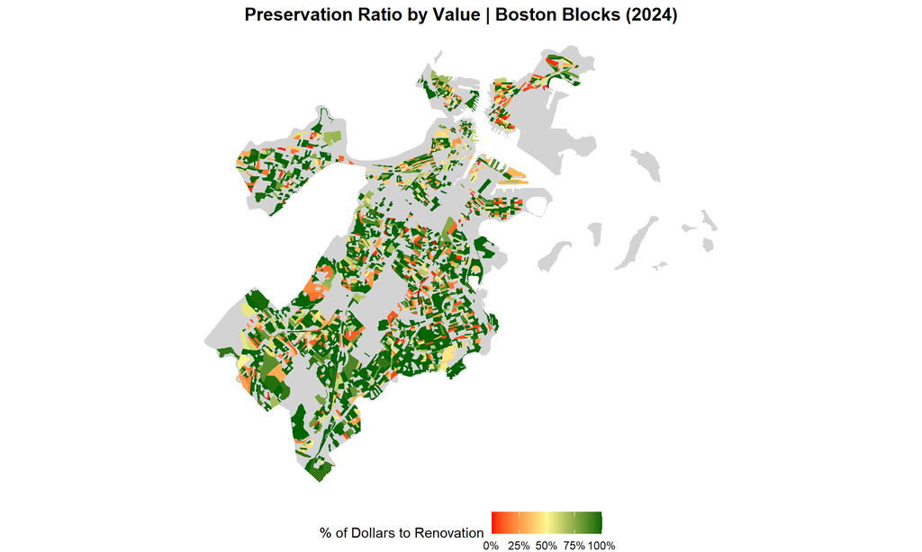

The map reveals distinct geographic clustering. Green areas where investment sustains existing structures through renovation concentrate in residential areas away from Boston’s urban core. Red areas, where new construction and demolition dominate cluster in downtown, Seaport, and waterfront neighborhoods where land values support replacement.

Blue Hill Avenue shows predominantly green coloring, indicating higher preservation ratios than expected given the corridor’s demographic characteristics. This contrasts sharply with downtown and waterfront areas where redevelopment dominates.

Gray areas (64% of Boston’s blocks) reflect the geographic distribution of development activity in 2024. Many residential blocks had little to no permitted construction, fewer than three projects, or only government work.

### Distribution of Preservation Values

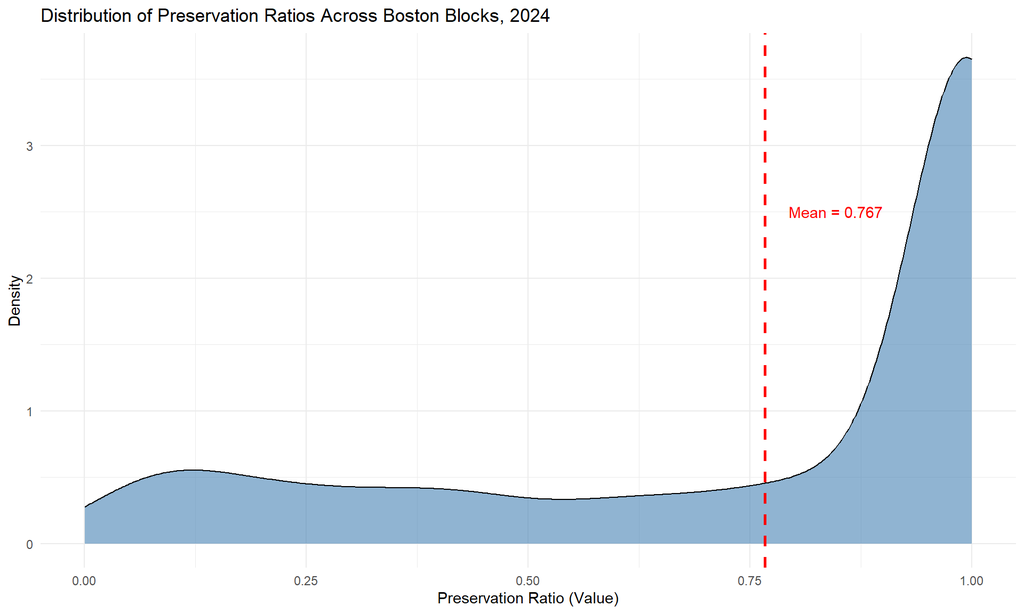

Table 1: Summary Statistics - Preservation Ratio (Value), N=2,146 blocks

| Mean | Median | SD | Min | Max | Q1 | Q3 |
| --- | --- | --- | --- | --- | --- | --- |
| 0.767 | 1 | 0.328 | 0 | 1 | 0.543 | 1 |

Table 2: Distribution of Blocks by Preservation Level

| Preservation Category | Number of Blocks | Percentage |
| --- | --- | --- |
| High Preservation (≥70%) | 1486 | 69.2 |
| Low Preservation (<40%) | 427 | 19.9 |
| Moderate Preservation (40-70%) | 233 | 10.9 |

The summary statistics provide a precise snapshot of this pattern. The mean ratio is 0.767, but the median is 1.0. This discrepancy between the average and the middle value is a classic sign of a skewed distribution. The standard deviation is 0.328, indicating considerable variation from block to block. The full range runs from 0 (all investment in redevelopment) to 1 (all investment in renovation).

### Correlation Analysis

To understand how preservation patterns relate to investment intensity, I examined bivariate correlations at the block level (N = 2,146).

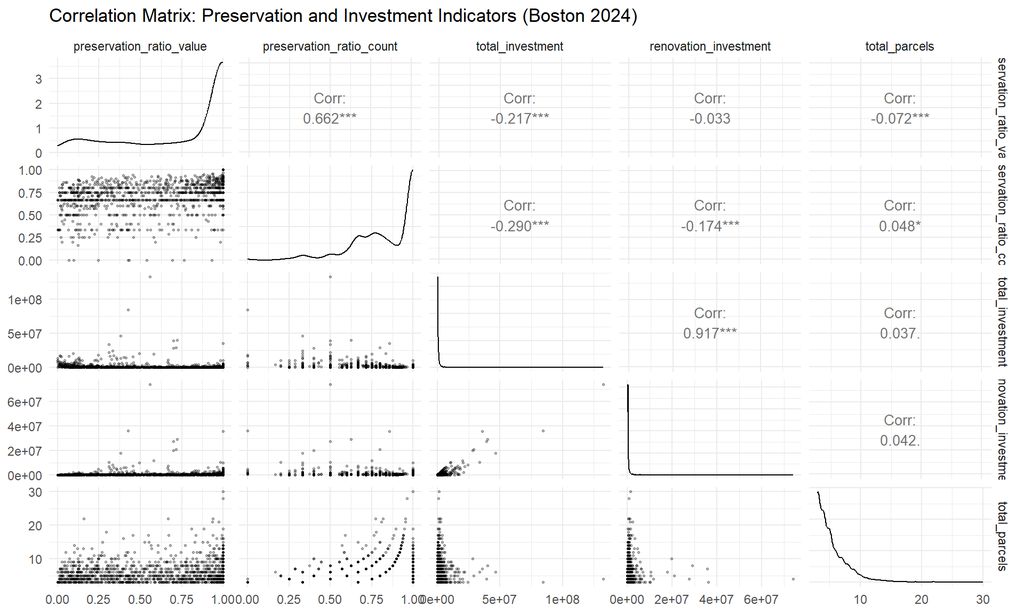

**Figure 3: Correlation Matrix of Preservation and Investment Indicators, Boston 2024.** Strong positive correlation (r=0.66, p<0.001) between count and value ratios confirms consistency. Moderate negative correlation (r=-0.22, p<0.001) between total investment and preservation indicates high-investment blocks shift toward redevelopment. Very strong correlation (r=0.92, p<0.001) between total and renovation investment shows renovation dollars increase absolutely while decreasing proportionally. Parcel counts show weak correlations (r<0.08).

Table 3: Correlation Coefficients (Pearson’s r)

|  | preservation_ratio_value | preservation_ratio_count | total_investment | renovation_investment | total_parcels |
| --- | --- | --- | --- | --- | --- |
| preservation_ratio_value | 1.000 | 0.662 | -0.217 | -0.033 | -0.072 |
| preservation_ratio_count | 0.662 | 1.000 | -0.290 | -0.174 | 0.048 |
| total_investment | -0.217 | -0.290 | 1.000 | 0.917 | 0.037 |
| renovation_investment | -0.033 | -0.174 | 0.917 | 1.000 | 0.042 |
| total_parcels | -0.072 | 0.048 | 0.037 | 0.042 | 1.000 |

Table 4: P-values for Correlations

|  | preservation_ratio_value | preservation_ratio_count | total_investment | renovation_investment | total_parcels |
| --- | --- | --- | --- | --- | --- |
| preservation_ratio_value | NA | 0.0000 | 0.0000 | 0.1235 | 0.0008 |
| preservation_ratio_count | 0.0000 | NA | 0.0000 | 0.0000 | 0.0266 |
| total_investment | 0.0000 | 0.0000 | NA | 0.0000 | 0.0867 |
| renovation_investment | 0.1235 | 0.0000 | 0.0000 | NA | 0.0506 |
| total_parcels | 0.0008 | 0.0266 | 0.0867 | 0.0506 | NA |

**Key findings**:

The correlation analysis revealed several key insights about how investment and development patterns relate in Boston:

1. **Internal consistency** : The ratio calculated by project count and the ratio calculated by dollar value are closely aligned (r = 0.662, p < 0.001). This means that in most blocks, if renovation projects outnumber other types, renovation dollars also tend to dominate the financial investment. This correlation validates that we are measuring a coherent neighborhood pattern, not just statistical noise.
2. **High investment predicts lower preservation** There is a significant negative correlation (r = -0.217, p < 0.001) between the total amount of money invested in a block and its preservation ratio. Simply put, blocks that attract major capital investment tens of millions of dollars tend to see that money flow toward new construction and demolition, not renovation. This confirms a core community observation: big money tends to transform neighborhoods rather than maintain them.
3. **Renovation increases absolutely but decreases proportionally** : There is an extremely strong positive correlation (r = 0.917, p < 0.001) between total investment and the absolute dollar amount spent on renovation. However, because the share of money going to renovation falls (as shown in finding #2), this means that while more renovation is happening everywhere in dollar terms, its relative importance shrinks dramatically when large-scale redevelopment enters the picture.
4. **Project density unrelated to orientation** :The correlation between the density of projects (total parcels) and the preservation ratio is essentially zero (r < 0.08). A block with many projects could be full of small renovations or a mix of new constructions; a block with few projects could be seeing minor updates or one massive redevelopment. Activity level alone does not predict whether a neighborhood is being preserved or redeveloped. redevelopment

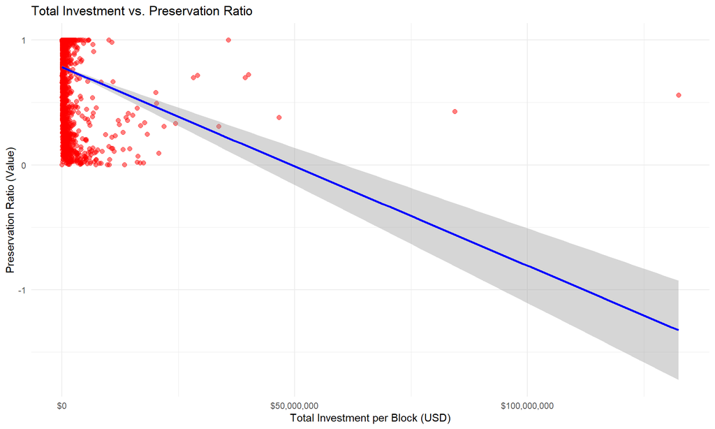

These correlations validate community observations, thus major financial pressure tends to bring redevelopment. This figure shows that blocks with modest levels of construction activity display a wide mix of renovation and redevelopment oriented investment. However, as total investment per block increases, the share of dollars going to renovations tends to fall. The handful of blocks receiving very large capital inflows are disproportionately characterized by low preservation ratios, indicating that major investments in Boston are more likely to take the form of new construction or large additions rather than repairs to existing buildings.

### Group Comparisons: T-Tests

Analysis was conducted at the census tract level (N = 188 tracts) to enable comparisons with demographic data. These tests examine whether simple neighborhood characteristics predict differences in preservation patterns

#### Blue Hill Avenue vs. Other Boston

**Research question**: Does Blue Hill Avenue show different preservation patterns in simple geographic comparison?

An independent samples t-test was conducted to compare the mean preservation ratios of Blue Hill Avenue tracts (n = 23) with all other Boston tracts (n = 165). This test examines whether simply being located in the Blue Hill corridor predicts a different type of investment pattern.

**Results**: Results show that Blue Hill Avenue’s development pattern, when measured by the Preservation Ratio, looks remarkably similar to the rest of Boston. The corridor’s 23 tracts had an average preservation ratio of 0.748, meaning about 75% of investment dollars went to renovation. This was nearly identical to the 0.766 average found across 165 other Boston tracts. The statistical test confirms this similarity: with a t-value of -0.63 and a p-value of 0.53, the difference between the two areas is not statistically significant. it could easily be due to random variation rather than a true underlying pattern.

**Interpretation**: This finding is both surprising and revealing. Despite the distinct community identity along Blue Hill Avenue and residents’ specific concerns about displacement pressure, the raw numbers show that the corridor experiences the same balance of renovation versus redevelopment investment as the city overall. Geographic location alone, simply being in the Blue Hill corridor versus elsewhere in Boston does not predict whether a neighborhood will see more preservation-focused or redevelopment-focused investment. This null result challenges simple assumptions and points to a more complex story. It motivated the deeper investigation into ownership structure that followed, where we discovered that while Blue Hill looks similar on the surface, it responds very differently to corporate investment than other parts of the city

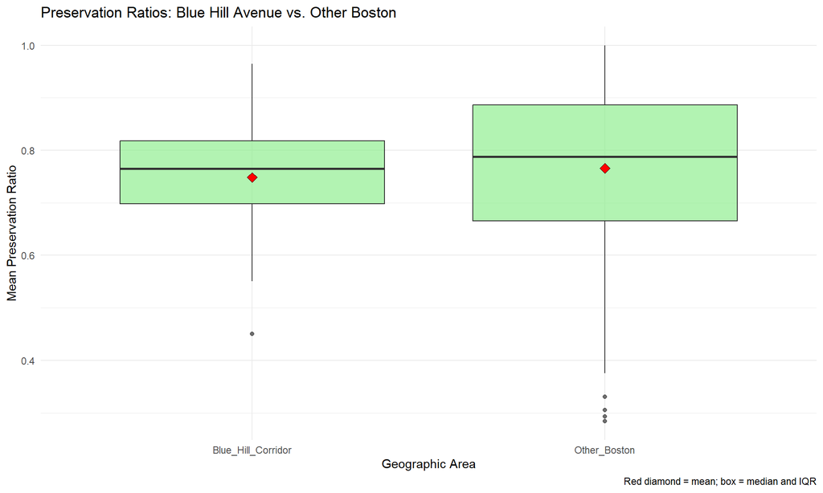

**Figure 5: Preservation Ratios by Geographic Area.** Boxplots comparing Blue Hill (23 tracts) to other Boston (165 tracts). Medians nearly identical, IQRs overlap substantially. No significant difference (t=-0.63, p=0.53) indicates simple geographic categorization doesn’t explain variation. Regression later revealed Blue Hill responds differently to corporate ownership not visible in this unconditional comparison.

#### Majority-Minority vs. Other Tracts

**Research question**: Do neighborhoods where minorities are the majority show different preservation patterns?

```
## Majority-Minority vs. Other Tracts
```

```
## Majority-Minority: M = 0.77 , n = 58
```

```
## Other Tracts: M = 0.761 , n = 130
```

```
## t(117.8) = 0.39, p = 0.7
```

```
## Result: NOT statistically significant
```

**Results**: A comparison of development patterns between majority-minority neighborhoods and other tracts revealed no significant difference in preservation ratios. The 58 majority-minority tracts (where Black and Hispanic residents constitute over 50% of the population) maintained an average preservation ratio of 0.770, while the 130 other tracts averaged 0.761. This difference of less than 1 percentage point was not statistically significant (t(117.8) = 0.39, p = 0.70), indicating that the two groups are essentially indistinguishable in terms of their development orientation.

**Interpretation**: Racial composition alone does not predict preservation vs. redevelopment orientation. This finding challenges common assumptions about how race and development intersect in Boston’s neighborhoods. Despite historical patterns of segregation and disinvestment, majority-minority neighborhoods show the same balance of renovation versus redevelopment investment as other areas of the city. Racial composition alone, whether a neighborhood is predominantly communities of color or not does not predict whether it will experience preservation-focused or redevelopment-focused investment. This suggests that the economic and market forces driving development decisions operate across racial lines, or that other factors like property ownership patterns, zoning regulations, and land values are stronger determinants of development type than neighborhood demographics. The finding reinforces the broader pattern emerging from this analysis: simple demographic categories cannot explain the complex landscape of neighborhood investment in Boston

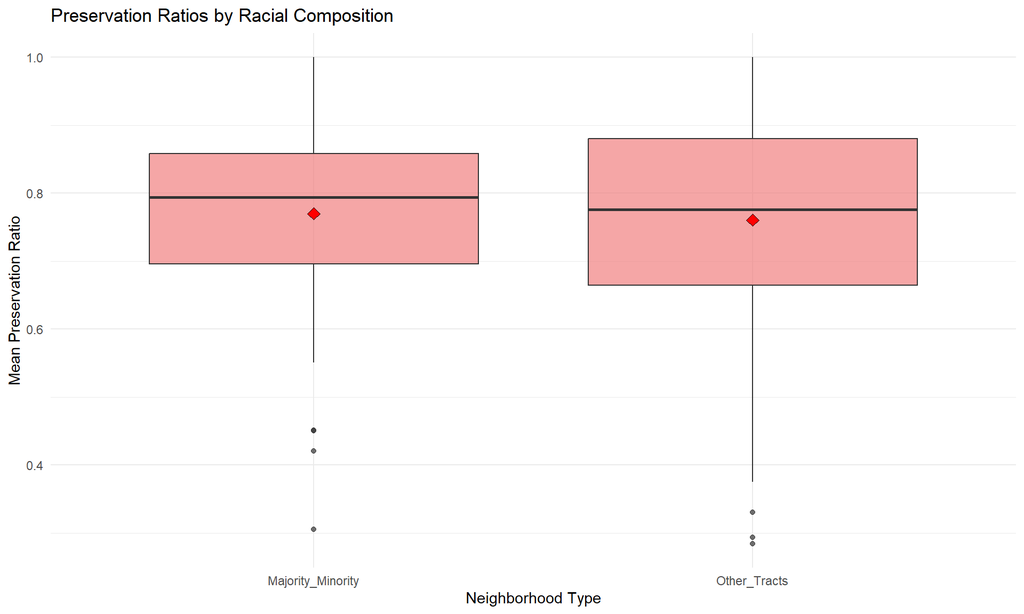

**Figure 6: Preservation Ratios by Racial Composition.** Nearly identical distributions for majority-minority (58 tracts) and other tracts (130 tracts). Medians around 0.78, similar IQRs. The 0.9 percentage point difference not significant (t=0.39, p=0.70).

### Group Comparisons: ANOVA by Income Level

**Research question**: Do neighborhoods with different income levels show different preservation patterns?

To answer this, we need to know if preservation patterns differ systematically between low-income, middle-income, and high-income areas. The community’s concern about displacement often centers on economic pressure. The fear that rising property values and outside investment will transform lower-income neighborhoods. This analysis tests whether those neighborhoods actually show different investment patterns in the data.

**Income categories**: Tracts were divided into three groups based on median household income from the American Community Survey Low income: Less than $50,000 annually (n = 33 tracts)

Middle income: Between $50,000 and $80,000 (n = 43 tracts)

High income: $80,000 or more (n = 112 tracts)

These categories capture meaningful economic distinctions while ensuring each group has enough tracts for reliable statistical comparison. The distribution reflects Boston’s economic geography, with more tracts falling into the high-income category, consistent with the city’s overall affluence alongside concentrated lower-income areas.

**Interpretation**: This finding challenges common assumptions about how income relates to development pressure. Contrary to expectations that lower income neighborhoods might face different types of investment (either more redevelopment due to speculation or more preservation due to lack of investment), the data shows that neighborhoods across the income spectrum experience remarkably similar mixes of renovation and redevelopment. The follow up Tukey HSD tests confirm this pattern, finding no statistically significant differences between any of the income group pairs (all p-values > 0.35). This suggests that the economic forces driving development decisions, whether to renovate existing buildings or replace them operate similarly across neighborhoods regardless of residents’ income levels. Just as with geography and racial composition, income alone cannot explain why some areas see more preservation while others see more redevelopment. This consistent pattern of null findings across demographic factors points to the need to look beyond who lives in a neighborhood and examine who owns property there and how different types of owners make investment decisions.. **Neighborhood income does not predict preservation patterns.**

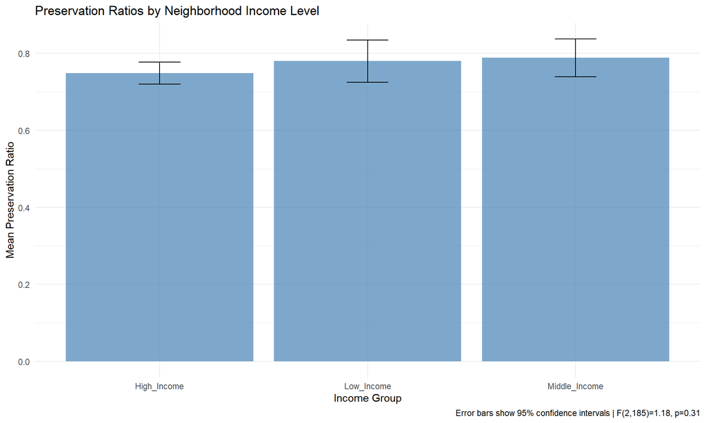

**Figure 7: Mean Preservation Ratios by Income Level.** Bar chart with 95% confidence intervals. Despite apparent gradient (low=78.0%, high=74.9%), CIs overlap substantially. ANOVA confirms no significance (F=1.18, p=0.31). Wide error bars reflect within-group variation. N=188 tracts.

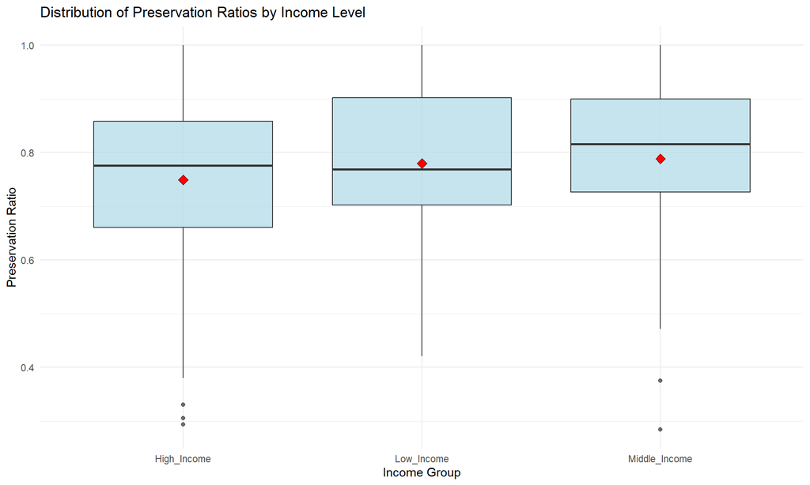

**Figure 8: Distribution by Income Level.** Boxplots show why ANOVA found no significance despite apparent gradient. Similar medians, overlapping IQRs, comparable spread. High-income shows more low-preservation outliers but central tendencies indistinguishable.

### Multivariate Regression Analysis

Given null findings for demographics, I estimated four nested models testing whether ownership structure predicts development orientation (N = 188 tracts).

Table 6: Model Fit Comparison

| Model | Variables | R² | Adj. R² | Improvement over M1 |
| --- | --- | --- | --- | --- |
| Model 1 | Demographics Only | 0.052 | 0.041 | - |
| Model 2 | + Corporate Ownership | 0.112 | 0.097 | +117% |
| Model 3 | + Blue Hill Indicator | 0.123 | 0.103 | +137% |
| Model 4 | + Corporate × Blue Hill | 0.126 | 0.102 | +144% |

#### Model 1: Demographic Baseline

The regression analysis reveals a clear progression in understanding what drives preservation versus redevelopment patterns in Boston. Model 1, which includes only demographic variables (median income and racial composition), performs poorly, explaining just 5.2% of the variation in preservation ratios. This confirms what we saw in the earlier group comparisons: neither income nor racial demographics alone can predict whether a neighborhood will experience preservation-focused or redevelopment-focused investment.

#### Model 4: Interaction Model (Primary Finding)

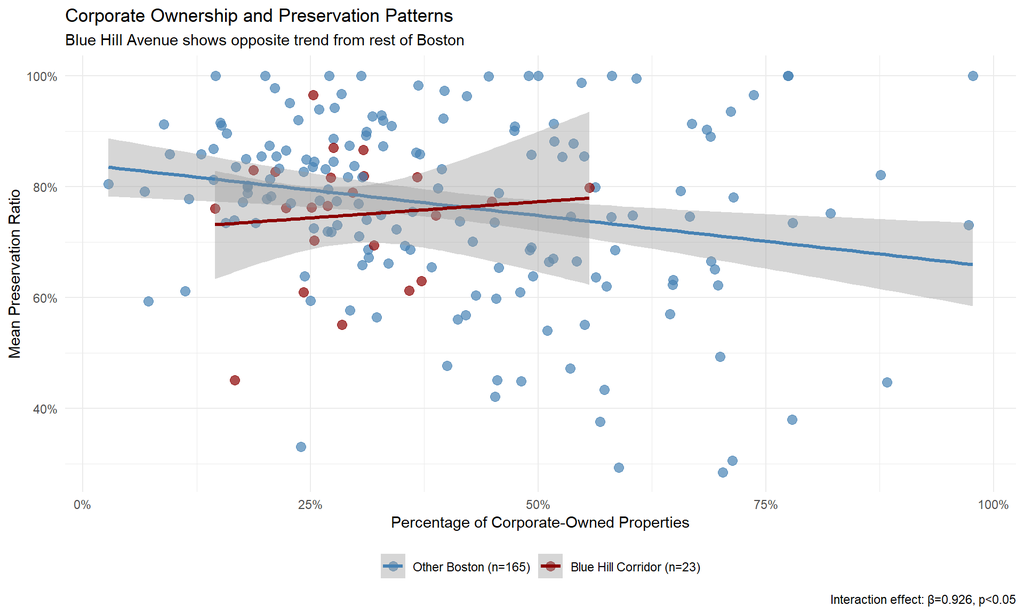

**Figure 9: Corporate Ownership and Preservation by Area.** Separate trend lines for Blue Hill (red, n=23) and other Boston (blue, n=165). Blue line slopes down (β=-0.329), red slopes up (net β=+0.597). Crossing lines show interaction effect (β=0.926, p<0.05).

### Critical Interpretation: What Preservation Ratios Cannot Measure

Field observations during this project revealed fundamental limitations in what the Preservation Ratio can and cannot tell us about neighborhood change. These limitations are crucial for understanding both the metric’s utility and its boundaries.

#### Limitation 1: Scale Blindness

The Preservation Ratio treats all investment dollars equally, but dollars can create very different physical realities. A $500,000 renovation next to a five-story building where a $2 million renovation would create 24 units. Both appear as “renovation” in our metric, but one adds significant housing density while the other does not. Similarly on Blue Hill Avenue, what appears as “preservation” in the data might involve subdividing units or converting basements into apartments. A density increases that are completely invisible to the ratio but have real impacts on neighborhood character and housing supply

#### Limitation 2: The Value Paradox

The case of a formerly abandoned building that was renovated into two dozen market rate apartments illustrates another key limitation. This project might contributed to high preservation statistics in its neighborhood, but served a completely different and more expensive market than what existed before. On Blue Hill Avenue, this same pattern could manifest as investors renovating properties not to maintain affordability, but to upgrade units in order to justify significant rent increases. The metric captures investment in existing structures but cannot distinguish between renovations that maintain community access and those that facilitate economic displacement. Blue Hill may reflect similar: renovate to justify rent increases.

#### Limitation 3: Corporate Classification Cannot Distinguish Intent

Our classification of “corporate” ownership captures legal structure but not mission. A community development corporation like DSNI’s land trust, working to preserve long-term affordability, appears identical in our data to a speculative investor flipping properties for profit. Both contribute to high corporate ownership statistics, and both tend to renovate rather than demolish, but their impacts on community stability are fundamentally opposite. This is particularly significant for Blue Hill Avenue, where both types of corporate owners operate simultaneously.

#### Limitation 4: Temporal Gaps

Building permits capture moments of construction, not longer trajectories of neighborhood change. Properties that sit vacant for years before renovation periods that often destabilize blocks and depress property values are invisible in our 2024 snapshot. Similarly, properties being “warehoused” (purchased and left empty in anticipation of future development) do not appear until permits are filed. The metric shows what is happening now but not the pressures that have been building or the futures that investors are anticipating

### Reconciling Statistics with Community Testimony

The tension between statistical findings and community experience is perhaps most pronounced in Blue Hill Avenue’s story. The data shows high preservation (74.8%) and a positive relationship between corporate ownership and preservation yet DSNI members report ongoing displacement pressure. Both accounts are true, and understanding why requires looking beyond the numbers.

Three interconnected mechanisms could explain this apparent paradox. First, constrained redevelopment: community organizing may have successfully limited demolition but cannot prevent economic displacement through rent increases after renovation. Second, market-driven renovation: investors may find renovation more profitable than new construction in the corridor’s current market conditions. Third, a mixed model: community development corporations preserve some affordable units while speculative investors pursue a “renovate-to-displace” strategy on others, both contributing to the same statistical pattern.

The crucial insight is that the Preservation Ratio measures investment type, not community impact. It tells us whether development dollars are maintaining existing structures (renovation) or replacing them (redevelopment). But it cannot tell us who benefits from that investment or what happens to current residents. Blue Hill Avenue may have influenced how development occurs toward renovation rather than demolition, but DSNI’s testimony shows this has not prevented displacement outcomes. Renovation, when done for market rate profit rather than community stability, can displace residents just as effectively as demolition, just through different economic mechanisms.

This distinction is vital for community organizing and policy advocacy. It means that fighting displacement requires addressing both pathways: not just preventing demolition, but also ensuring that renovation serves existing residents through rent stabilization, affordability covenants, and protections against speculative flipping. The Preservation Ratio gives communities a tool to monitor the first pathway, but they need other tools and their own testimony to address the second.

## Conclusion

The Preservation Ratio provides community members, organizers, and policymakers with a straightforward, replicable method for tracking the basic orientation of neighborhood investment. Does the money flowing into a neighborhood maintain what already exists, or replace it? Applied to 2,146 active census blocks across Boston in 2024, the measure reveals consistent patterns, most notably that corporate ownership is a powerful predictor of redevelopment oriented investment citywide , except along the Blue Hill Avenue corridor, where a significant and important exception exists.

**However, high preservation ratios do not guarantee community benefit.** : A crucial caution, however, emerges from both the data and on the ground observation: a high preservation ratio does not automatically signal community benefit. Renovating an existing building can displace residents through subsequent rent increases or ownership turnover just as effectively as demolishing it. The metric tracks the form of capital investment, not its impact on housing stability

### Key Findings

1. **Demographics do not predict preservation**: Simple comparisons revealed no statistically significant differences in preservation patterns based on a neighborhood’s geographic location, racial composition, or income level alone. The story of whether a block experiences renovation or redevelopment is not simply about who lives there.
2. **Corporate ownership predicts redevelopment**: Multivariate regression confirmed that across most of Boston, a higher percentage of corporate owned properties strongly predicts a lower preservation ratio (β = -0.329, p < 0.001). This validates a core community concern about the role of outside institutional capital.
3. **Blue Hill Avenue shows protective interaction**: The most telling finding is an interaction effect: on the Blue Hill corridor, the relationship between corporate ownership and preservation reverses (β = 0.926, p < 0.05). While more corporate ownership means less preservation elsewhere, it correlates with more preservation on Blue Hill. This suggests the corridor operates under a different set of market or community dynamics.
4. **Statistics require cautious interpretation**: The statistical portrait of Blue Hill showing high preservation coexists with direct testimony from DSNI members about ongoing displacement pressure. This paradox underscores the need to interpret data alongside lived experience.

### Implications for Communities

For organizations like the Dudley Street Neighborhood Initiative and residents of the Blue Hill corridor, the Preservation Ratio is best understood as one tool among many. Its power lies in its ability to map the geography of investment type and monitor changes over time, providing quantitative backing for community observations.

To use this tool effectively, communities should:

**Communities should**:

1. Track it annually to spot meaningful shifts in development pressure.
2. Combine qualitative testimony from tenants to understand the human impact behind the numbers.
3. Monitor it alongside other indicators like rent data, eviction filings, and property sales.
4. Generate strategic questions for organizing and advocacy, not as a definitive answer about community well-being.

Blue Hill Avenue’s unique statistical pattern demonstrates that communities can influence how development manifests in this case, toward renovation rather than demolition. Yet DSNI’s reports confirm that influencing the form has not, by itself, prevented displacement outcomes. Both realities are true and highlight the need for policies that address both demolition-driven and renovation-driven displacement.

### Limitations

This analysis has inherent constraints: it is a single year snapshot (2024), cannot distinguish between mission driven and speculative corporate owners, treats all renovations as equal, and excludes the majority of Boston’s blocks due to low activity. Future work should track the ratio over time, refine ownership classifications, and most importantly, correlate it directly with data on tenant outcomes.

Ultimately, the value of the Preservation Ratio is as a complement to, not a replacement for, community knowledge. It provides a quantitative lens through which to view neighborhood change, helping to answer a critical question when residents feel the pressure of displacement. Is the threat coming through the bulldozer, or through the renovation crew? Both pathways require different, but equally urgent, community responses

## Appendix A: Data Dictionary

### Record-Level Variables (Building Permits Database)

**Original variables**:

`PermitNumber`: Unique permit identifier  
`DECLARED_VALUATION` : Estimated monetary value (dollars) `ISSUED_DATE` : Date permit issued `Land_Parcel_ID` : Unique property parcel identifier `Blk_ID_20` : 2020 Census block ID (15-digit GEOID) `owner` : Property owner name `government` : Government project indicator (1=yes, 0=no) `newcon`, `reno`, `addition`, `demo` : Project type binary indicators

**NEW variables created**:

`year` : Extracted from `ISSUED_DATE` (first 4 characters) `corporate_owner` : Binary: 1 if owner contains LLC/INC/CORP/TRUST/ASSOC/PARTNERSHIP, 0 otherwise

### Parcel-Level Variables (NEW - Aggregated from Permits)

`Land_Parcel_ID` : Unique property identifier `project_type` : Categorical (new_construction, demolition, addition, renovation, other) `total_investment` : Sum of valuations for parcel `renovation_investment` : Sum of valuations for renovation permits only `Blk_ID_20` : Census block ID

**Sample size**: 14,042 parcels (2024)

### Block-Level Variables (NEW - Aggregated from Parcels)

`Blk_ID_20` : Census block identifier `total_parcels` : Count of projects in block `renovation_parcels` : Count of renovation projects `total_investment` : Sum of investment in block `renovation_investment` : Sum of renovation investment  
`preservation_ratio_value` : **PRIMARY METRIC**: `renovation_investment / total_investment` (0-1 scale) `preservation_ratio_count` : Alternative: `renovation_parcels / total_parcels`

**Sample size**: 2,146 blocks with 3+ projects

### Tract-Level Variables (NEW - Aggregated from Blocks + ACS)

`tract_id` : 11-digit census tract ID (first 11 characters of `Blk_ID_20`)

`mean_preservation_ratio`: Mean of `preservation_ratio_value` across blocks in tract

`total_investment_tract` : Sum of block-level `total_investment`

`n_blocks` : Count of blocks in tract

`pct_corporate` : Percentage of permits with corporate ownership

`blue_hill_corridor` : Binary: 1=Blue Hill Avenue tract, 0=other

`median_income` : From ACS variable B19013_001

`total_population` : From ACS variable B01003_001

`pct_minority` : Calculated: (Black + Hispanic) / Total Population × 100

`income_group` : Categorical: Low (<$50K), Middle ($50-80K), High (≥$80K)

`majority_minority` : Binary: 1 if `pct_minority > 50`

**Sample size**: 188 tracts

25025980300, 25025081400, 25025080300, 25025091300, 25025082100, 25025091400, 25025081800, 25025090200, 25025091200, 25025091500, 25025091800, 25025091900, 25025091700, 25025081700, 25025081900, 25025090600, 25025080100, 25025081500, 25025090300, 25025082000, 25025090100, 25025090400, 25025090700, 25025081302

## Appendix B: Annotated R Syntax

```r
# ============================================================================
# SETUP: LOAD LIBRARIES AND SET API KEY
# ============================================================================

library(tidyverse)
library(sf)
library(ggplot2)
library(Hmisc)
library(GGally)
library(tidycensus)
library(stargazer)
library(conflicted)

# Resolve function name conflicts
conflict_prefer("select", "dplyr")
conflict_prefer("filter", "dplyr")
conflict_prefer("summarize", "dplyr")

# Set Census API key (get free key from https://api.census.gov/data/key_signup.html)
census_api_key("1dba571005040543a451132f80d5504f5c3e8592", install = TRUE, overwrite = TRUE)

# ============================================================================
# LOAD DATA
# ============================================================================

# Load building permits database (691,985 records covering 2006-2024)
permit_data <- read.csv("D:/NEU/PPUA5262 BIG DATA/Permits.Records.Geocoded.2025.csv")

# Load census block shapefiles (5,975 census blocks in Boston)
blocks_geo <- st_read("D:/NEU/PPUA5262 BIG DATA/Making maps/Blocks_Boston_2020_BARI.shp")

cat("Data loaded successfully\n")
cat("Building permits:", nrow(permit_data), "records\n")
cat("Census blocks:", nrow(blocks_geo), "blocks\n\n")

# ============================================================================
# STEP 1: FILTER TO 2024 COMMUNITY PROJECTS
# ============================================================================

permits_2024 <- permit_data %>%
  mutate(year = as.integer(substr(ISSUED_DATE, 1, 4))) %>%
  filter(
    year == 2024,
    government == 0,
    DECLARED_VALUATION > 0,
    DECLARED_VALUATION < 1e7,
    newcon == 1 | reno == 1 | addition == 1 | demo == 1
  )

cat("STEP 1 COMPLETE: Filtered to", nrow(permits_2024), "permits for 2024 community projects\n\n")

# ============================================================================
# STEP 2: AGGREGATE TO PARCEL LEVEL
# ============================================================================

parcel_2024 <- permits_2024 %>%
  group_by(Land_Parcel_ID) %>%
  summarise(
    # Classify project type hierarchically (newcon > demo > addition > reno)
    project_type = case_when(
      any(newcon == 1)   ~ "new_construction",
      any(demo == 1)     ~ "demolition",
      any(addition == 1) ~ "addition",
      any(reno == 1)     ~ "renovation",
      TRUE               ~ "other"
    ),
    # Sum declared valuations across all permits for this parcel
    total_investment      = sum(DECLARED_VALUATION, na.rm = TRUE),
    renovation_investment = sum(DECLARED_VALUATION[reno == 1], na.rm = TRUE),
    # Carry forward census block identifier
    Blk_ID_20 = first(Blk_ID_20),
    .groups = "drop"
  )

cat("STEP 2 COMPLETE: Created", nrow(parcel_2024), "unique projects (parcels)\n\n")

# ============================================================================
# STEP 3: CALCULATE BLOCK-LEVEL PRESERVATION RATIOS
# ============================================================================

equitable_data <- parcel_2024 %>%
  filter(!is.na(Blk_ID_20)) %>%
  group_by(Blk_ID_20) %>%
  summarise(
    # Count projects
    total_parcels      = n(),
    renovation_parcels = sum(project_type == "renovation"),
    # Sum investments
    total_investment      = sum(total_investment, na.rm = TRUE),
    renovation_investment = sum(renovation_investment, na.rm = TRUE),
    # Calculate preservation ratios
    preservation_ratio_count = renovation_parcels / total_parcels,
    preservation_ratio_value = renovation_investment / total_investment,
    .groups = "drop"
  ) %>%
  filter(total_parcels >= 3)  # Keep only blocks with 3+ projects for stability

cat("STEP 3 COMPLETE: Created preservation ratios for", nrow(equitable_data), "census blocks\n")
cat("Excluded", 5975 - nrow(equitable_data), "blocks with fewer than 3 projects\n\n")

# ============================================================================
# STEP 4: CREATE CORPORATE OWNERSHIP VARIABLE
# ============================================================================

permit_data_enhanced <- permit_data %>%
  mutate(
    corporate_owner = case_when(
      grepl("LLC|INC|CORP|TRUST|ASSOC|PARTNERSHIP", toupper(owner)) ~ 1,
      TRUE ~ 0
    )
  )

cat("STEP 4 COMPLETE: Created corporate ownership indicator\n")
cat("Corporate-owned permits:", sum(permit_data_enhanced$corporate_owner, na.rm = TRUE), "\n\n")

# ============================================================================
# STEP 5: PULL DEMOGRAPHIC DATA FROM CENSUS
# ============================================================================

demographic_data <- get_acs(
  geography = "tract",
  variables = c(
    median_income = "B19013_001",
    total_population = "B01003_001",
    black_population = "B02001_003",
    hispanic_population = "B03001_003",
    white_population = "B02001_002"
  ),
  state = "MA",
  county = "Suffolk",
  year = 2023,
  output = "wide"
)

# Clean and prepare demographic data
demographic_clean <- demographic_data %>%
  dplyr::select(GEOID, median_incomeE, total_populationE,
                black_populationE, hispanic_populationE, white_populationE) %>%
  dplyr::rename(
    median_income = median_incomeE,
    total_population = total_populationE,
    black_population = black_populationE,
    hispanic_population = hispanic_populationE,
    white_population = white_populationE
  ) %>%
  dplyr::mutate(
    pct_minority = (black_population + hispanic_population) / total_population * 100,
    pct_black = black_population / total_population * 100
  )

cat("STEP 5 COMPLETE: Retrieved demographic data for", nrow(demographic_clean), "census tracts\n\n")

# ============================================================================
# STEP 6: DEFINE BLUE HILL AVENUE CORRIDOR
# ============================================================================

# 23 census tracts identified by DSNI as comprising Blue Hill Avenue corridor
blue_hill_tracts <- c(
  "25025980300", "25025081400", "25025080300", "25025091300", "25025082100",
  "25025091400", "25025081800", "25025090200", "25025091200", "25025091500",
  "25025091800", "25025091900", "25025091700", "25025081700", "25025081900",
  "25025090600", "25025080100", "25025081500", "25025090300", "25025082000",
  "25025090100", "25025090400", "25025090700", "25025081302"
)
```

```r
cat("STEP 6 COMPLETE: Defined", length(blue_hill_tracts), "Blue Hill Avenue corridor tracts\n\n")

# ============================================================================
# STEP 7: AGGREGATE TO TRACT LEVEL
# ============================================================================

# Aggregate block-level preservation ratios to tract level
tract_preservation <- equitable_data %>%
  mutate(tract_id = substr(Blk_ID_20, 1, 11)) %>%
  group_by(tract_id) %>%
  dplyr::summarise(
    mean_preservation_ratio = mean(preservation_ratio_value, na.rm = TRUE),
    total_investment = sum(total_investment, na.rm = TRUE),
    n_blocks = n(),
    .groups = "drop"
  )

cat("Aggregated blocks to tracts:", nrow(tract_preservation), "tracts\n")

# Calculate corporate ownership percentage by tract
tract_corporate <- permit_data_enhanced %>%
  mutate(
    year = as.integer(substr(ISSUED_DATE, 1, 4)),
    tract_id = substr(Blk_ID_20, 1, 11)
  ) %>%
  filter(year == 2024, government == 0) %>%
  group_by(tract_id) %>%
  dplyr::summarise(
    pct_corporate = mean(corporate_owner, na.rm = TRUE) * 100,
    .groups = "drop"
  )

cat("Calculated corporate ownership for tracts:", nrow(tract_corporate), "tracts\n\n")

cat("STEP 7 COMPLETE: Tract-level aggregation finished\n\n")

# ============================================================================
# STEP 8: CREATE FINAL TRACT ANALYSIS DATASET
# ============================================================================

# Merge preservation ratios with corporate ownership and demographics
tract_analysis <- tract_preservation %>%
  left_join(tract_corporate, by = "tract_id") %>%
  left_join(demographic_clean, by = c("tract_id" = "GEOID")) %>%
  mutate(blue_hill_corridor = ifelse(tract_id %in% blue_hill_tracts, 1, 0)) %>%
  filter(!is.na(mean_preservation_ratio) & !is.na(median_income))

cat("Final tract analysis dataset:", nrow(tract_analysis), "tracts with complete data\n")

# Create categorical variables for group comparisons
analysis_data <- tract_analysis %>%
  mutate(
    # Income groups for ANOVA
    income_group = case_when(
      median_income < 50000 ~ "Low_Income",
      median_income < 80000 ~ "Middle_Income",
      median_income >= 80000 ~ "High_Income",
      TRUE ~ NA_character_
    ),
    # Blue Hill label for t-test
    blue_hill_label = ifelse(blue_hill_corridor == 1,
                             "Blue_Hill_Corridor",
                             "Other_Boston"),
    # Majority-minority label for t-test
    majority_minority = ifelse(pct_minority > 50,
                               "Majority_Minority",
                               "Other_Tracts")
  ) %>%
  filter(!is.na(income_group))

cat("Analysis dataset with categorical variables:", nrow(analysis_data), "tracts\n\n")

cat("STEP 8 COMPLETE: All data preparation finished\n")
cat("Ready for statistical analysis\n\n")

# ============================================================================
# DESCRIPTIVE STATISTICS
# ============================================================================


# Basic summary
cat("Summary of Preservation Ratio (Value) at Block Level (N=", nrow(equitable_data), "):\n")
cat("--------------------------------------------------------------------------------\n")
summary(equitable_data$preservation_ratio_value)

# Detailed summary statistics
summary_stats <- equitable_data %>%
  summarise(
    Mean = mean(preservation_ratio_value, na.rm = TRUE),
    Median = median(preservation_ratio_value, na.rm = TRUE),
    SD = sd(preservation_ratio_value, na.rm = TRUE),
    Min = min(preservation_ratio_value, na.rm = TRUE),
    Max = max(preservation_ratio_value, na.rm = TRUE),
    Q1 = quantile(preservation_ratio_value, 0.25, na.rm = TRUE),
    Q3 = quantile(preservation_ratio_value, 0.75, na.rm = TRUE)
  )

cat("\nDetailed Summary Statistics:\n")
print(summary_stats)

# Count blocks by preservation category
preservation_categories <- equitable_data %>%
  mutate(
    category = case_when(
      preservation_ratio_value >= 0.70 ~ "High Preservation (≥70%)",
      preservation_ratio_value >= 0.40 ~ "Moderate Preservation (40-70%)",
      preservation_ratio_value < 0.40 ~ "Low Preservation (<40%)"
    )
  ) %>%
  count(category) %>%
  mutate(Percentage = round(n / sum(n) * 100, 1))

cat("\nBlocks by Preservation Category:\n")
print(preservation_categories)

# ----------------------------------------------------------------------------
# FIGURE 2: DENSITY PLOT OF PRESERVATION RATIO DISTRIBUTION
# ----------------------------------------------------------------------------

ggplot(equitable_data, aes(preservation_ratio_value)) +
  geom_density(fill = "steelblue", alpha = 0.6) +
  geom_vline(aes(xintercept = mean(preservation_ratio_value)),
             linetype = "dashed", color = "red", size = 1) +
  annotate("text",
           x = mean(equitable_data$preservation_ratio_value) + 0.08,
           y = 2.5,
           label = paste0("Mean = ", round(mean(equitable_data$preservation_ratio_value), 3)),
           color = "red") +
  labs(
    title = "Distribution of Preservation Ratios Across Boston Blocks, 2024",
    x = "Preservation Ratio (Value)",
    y = "Density"
  ) +
  theme_minimal()


# ============================================================================
# SPATIAL VISUALIZATION (MAPPING)
# ============================================================================


# Prepare spatial data for merging - ensure matching ID types
blocks_geo <- blocks_geo %>%
  mutate(GEOID20 = as.character(GEOID20))

equitable_data <- equitable_data %>%
  mutate(Blk_ID_20 = as.character(Blk_ID_20))

# Merge preservation data with census block boundaries
blocks_merged <- blocks_geo %>%
  left_join(equitable_data, by = c("GEOID20" = "Blk_ID_20"))

cat("Merged preservation data with", nrow(blocks_merged), "census block boundaries\n")
cat("Blocks with preservation data:", sum(!is.na(blocks_merged$preservation_ratio_value)), "\n\n")


# ----------------------------------------------------------------------------
# FIGURE 1: CITYWIDE PRESERVATION RATIO CHOROPLETH MAP
# ----------------------------------------------------------------------------
```

```r
ggplot(blocks_merged) +
  geom_sf(aes(fill = preservation_ratio_value), color = NA, size = 0) +
  scale_fill_gradient2(
    low = "red",
    mid = "khaki1",
    high = "darkgreen",
    midpoint = 0.5,
    name = "% of Dollars to Renovation",
    limits = c(0, 1),
    labels = scales::percent,
    na.value = "lightgray"
  ) +
  labs(title = "Preservation Ratio by Value | Boston Blocks (2024)") +
  theme_void() +
  theme(
    plot.title = element_text(hjust = 0.5, face = "bold", size = 14),
    legend.position = "bottom"
  )


# ============================================================================
# CORRELATION ANALYSIS
# ============================================================================


# Prepare correlation dataset - select key variables
correlation_vars <- equitable_data %>%
  select(
    preservation_ratio_value,
    preservation_ratio_count,
    total_investment,
    renovation_investment,
    total_parcels
  ) %>%
  na.omit()

cat("Correlation analysis on", nrow(correlation_vars), "blocks (after removing missing values)\n\n")

# Calculate correlations with p-values using Hmisc::rcorr()
corr_results <- rcorr(as.matrix(correlation_vars))

cat("Correlation Coefficients (Pearson's r):\n")
cat("---------------------------------------\n")
print(round(corr_results$r, 3))

cat("\nP-values for Correlations:\n")
cat("--------------------------\n")
print(round(corr_results$P, 4))

# Key findings summary
cat("\nKey Correlation Findings:\n")
cat("- preservation_ratio_value <-> preservation_ratio_count: r =",
    round(corr_results$r["preservation_ratio_value", "preservation_ratio_count"], 3), "\n")
cat("- preservation_ratio_value <-> total_investment: r =",
    round(corr_results$r["preservation_ratio_value", "total_investment"], 3), "\n")
cat("- total_investment <-> renovation_investment: r =",
    round(corr_results$r["total_investment", "renovation_investment"], 3), "\n\n")


# ----------------------------------------------------------------------------
# FIGURE 3: CORRELATION MATRIX VISUALIZATION (ggpairs)
# ----------------------------------------------------------------------------

ggpairs(
  data = correlation_vars,
  columns = 1:5,
  title = "Correlation Matrix: Preservation and Investment Indicators (Boston 2024)",
  upper = list(continuous = wrap("cor", size = 3.5)),
  lower = list(continuous = wrap("points", alpha = 0.3, size = 0.5))
) +
  theme_minimal()


# ----------------------------------------------------------------------------
# FIGURE 4: SCATTERPLOT - TOTAL INVESTMENT VS PRESERVATION
# ----------------------------------------------------------------------------

ggplot(correlation_vars, aes(x = total_investment, y = preservation_ratio_value)) +
  geom_point(alpha = 0.5, color = "red", size = 2) +
  geom_smooth(method = "lm", se = TRUE, color = "blue", linewidth = 1) +
  scale_x_continuous(labels = scales::dollar) +
  labs(
    title = "Total Investment vs. Preservation Ratio",
    x = "Total Investment per Block (USD)",
    y = "Preservation Ratio (Value)"
  ) +
  theme_minimal()

# ============================================================================
# T-TESTS: GROUP COMPARISONS
# ============================================================================


# ----------------------------------------------------------------------------
# T-TEST 1: BLUE HILL AVENUE VS. OTHER BOSTON
# ----------------------------------------------------------------------------

blue_hill_ttest <- t.test(mean_preservation_ratio ~ blue_hill_label,
                          data = analysis_data)

cat("T-Test 1: Blue Hill Avenue vs. Other Boston\n")
cat("--------------------------------------------\n")
print(blue_hill_ttest)

# Calculate and display group statistics
blue_hill_summary <- analysis_data %>%
  group_by(blue_hill_label) %>%
  summarise(
    Mean = mean(mean_preservation_ratio),
    SD = sd(mean_preservation_ratio),
    N = n(),
    SE = SD / sqrt(N),
    .groups = "drop"
  )

cat("\nGroup Statistics:\n")
print(blue_hill_summary)

cat("\nInterpretation: Difference of",
    round(abs(diff(blue_hill_summary$Mean)), 3),
    "is NOT statistically significant (p =",
    round(blue_hill_ttest$p.value, 2), ")\n\n")

# ----------------------------------------------------------------------------
# FIGURE 5: BOXPLOT - BLUE HILL COMPARISON
# ----------------------------------------------------------------------------

ggplot(analysis_data, aes(x = blue_hill_label, y = mean_preservation_ratio)) +
  geom_boxplot(fill = "lightgreen", alpha = 0.7) +
  stat_summary(fun = mean, geom = "point", shape = 23, size = 3, fill = "red") +
  labs(
    title = "Preservation Ratios: Blue Hill Avenue vs. Other Boston",
    x = "Geographic Area",
    y = "Mean Preservation Ratio",
    caption = "Red diamond = mean; box = median and IQR"
  ) +
  theme_minimal()

# ----------------------------------------------------------------------------
# T-TEST 2: MAJORITY-MINORITY VS. OTHER TRACTS
# ----------------------------------------------------------------------------

minority_ttest <- t.test(mean_preservation_ratio ~ majority_minority,
                         data = analysis_data)

cat("\nT-Test 2: Majority-Minority vs. Other Tracts\n")
cat("---------------------------------------------\n")
print(minority_ttest)

# Calculate and display group statistics
minority_summary <- analysis_data %>%
  group_by(majority_minority) %>%
  summarise(
    Mean = mean(mean_preservation_ratio),
    SD = sd(mean_preservation_ratio),
    N = n(),
    SE = SD / sqrt(N),
    .groups = "drop"
  )

cat("\nGroup Statistics:\n")
print(minority_summary)

cat("\nInterpretation: Difference of",
    round(abs(diff(minority_summary$Mean)), 3),
    "is NOT statistically significant (p =",
    round(minority_ttest$p.value, 2), ")\n\n")


# ----------------------------------------------------------------------------
# FIGURE 6: BOXPLOT - MAJORITY-MINORITY COMPARISON
# ----------------------------------------------------------------------------
```

```r
ggplot(analysis_data, aes(x = majority_minority, y = mean_preservation_ratio)) +
  geom_boxplot(fill = "lightcoral", alpha = 0.7) +
  stat_summary(fun = mean, geom = "point", shape = 23, size = 3, fill = "red") +
  labs(
    title = "Preservation Ratios by Racial Composition",
    x = "Neighborhood Type",
    y = "Mean Preservation Ratio",
    caption = "Red diamond = mean; box = median and IQR"
  ) +
  theme_minimal()

# ============================================================================
# ANOVA: INCOME GROUPS
# ============================================================================


# Conduct one-way ANOVA
income_anova <- aov(mean_preservation_ratio ~ income_group,
                    data = analysis_data)

cat("ANOVA: Preservation Ratio by Income Group\n")
cat("------------------------------------------\n")
summary(income_anova)

# Extract F-statistic and p-value for interpretation
anova_summary <- summary(income_anova)[[1]]
cat("\nF-statistic:", round(anova_summary$`F value`[1], 2), "\n")
cat("p-value:", round(anova_summary$`Pr(>F)`[1], 2), "\n")
cat("Result: NOT statistically significant (p > 0.05)\n\n")

# Post-hoc Tukey HSD tests
cat("Tukey Post-Hoc Comparisons:\n")
cat("---------------------------\n")
tukey_results <- TukeyHSD(income_anova)
print(tukey_results)

# Calculate group means and standard errors
income_summary <- analysis_data %>%
  group_by(income_group) %>%
  summarise(
    Mean = mean(mean_preservation_ratio),
    SD = sd(mean_preservation_ratio),
    N = n(),
    SE = SD / sqrt(N),
    .groups = "drop"
  )

cat("\nGroup Means by Income Level:\n")
print(income_summary)

cat("\nInterpretation: Despite", round(max(income_summary$Mean) - min(income_summary$Mean), 3),
    "point spread, differences are NOT significant (F=1.18, p=0.31)\n\n")


# ----------------------------------------------------------------------------
# FIGURE 7: BAR CHART - INCOME GROUPS WITH ERROR BARS
# ----------------------------------------------------------------------------

# Calculate means and standard errors for plotting
income_means <- analysis_data %>%
  group_by(income_group) %>%
  summarise(
    mean = mean(mean_preservation_ratio),
    se = sd(mean_preservation_ratio) / sqrt(n()),
    .groups = "drop"
  )

# Create bar chart with 95% confidence intervals
ggplot(income_means, aes(x = income_group, y = mean)) +
  geom_bar(stat = "identity", fill = "steelblue", alpha = 0.7) +
  geom_errorbar(
    aes(ymin = mean - 1.96*se, ymax = mean + 1.96*se),
    width = 0.2
  ) +
  labs(
    title = "Preservation Ratios by Neighborhood Income Level",
    x = "Income Group",
    y = "Mean Preservation Ratio",
    caption = "Error bars show 95% confidence intervals | F(2,185)=1.18, p=0.31"
  ) +
  theme_minimal()

# ----------------------------------------------------------------------------
# FIGURE 8: BOXPLOT - INCOME GROUPS
# ----------------------------------------------------------------------------

ggplot(analysis_data, aes(x = income_group, y = mean_preservation_ratio)) +
  geom_boxplot(fill = "lightblue", alpha = 0.7) +
  stat_summary(fun = mean, geom = "point", shape = 23, size = 3, fill = "red") +
  labs(
    title = "Distribution of Preservation Ratios by Income Level",
    x = "Income Group",
    y = "Preservation Ratio",
    caption = "Red diamond = mean; box = median and IQR"
  ) +
  theme_minimal()

# ============================================================================
# MULTIVARIATE REGRESSION ANALYSIS
# ============================================================================


# ----------------------------------------------------------------------------
# MODEL 1: DEMOGRAPHICS ONLY (BASELINE)
# ----------------------------------------------------------------------------

model1 <- lm(mean_preservation_ratio ~ median_income + pct_minority,
             data = tract_analysis)

cat("Model 1: Demographics Only\n")
cat("--------------------------\n")
summary(model1)
cat("\nR-squared:", round(summary(model1)$r.squared, 3), "\n")
cat("Adjusted R-squared:", round(summary(model1)$adj.r.squared, 3), "\n")
cat("Interpretation: Demographics explain only 5.2% of variation\n\n")

# ----------------------------------------------------------------------------
# MODEL 2: ADD CORPORATE OWNERSHIP
# ----------------------------------------------------------------------------

model2 <- lm(mean_preservation_ratio ~ median_income + pct_minority + pct_corporate,
             data = tract_analysis)

cat("Model 2: + Corporate Ownership\n")
cat("-------------------------------\n")
summary(model2)
cat("\nR-squared:", round(summary(model2)$r.squared, 3), "\n")
cat("Adjusted R-squared:", round(summary(model2)$adj.r.squared, 3), "\n")
cat("Improvement over Model 1:",
    round((summary(model2)$r.squared/summary(model1)$r.squared - 1)*100), "%\n")
cat("Key finding: Corporate ownership β =", round(coef(model2)["pct_corporate"], 3),
    "(p < 0.001)\n\n")

# ----------------------------------------------------------------------------
# MODEL 3: ADD BLUE HILL CORRIDOR INDICATOR
# ----------------------------------------------------------------------------

model3 <- lm(mean_preservation_ratio ~ median_income + pct_minority +
               pct_corporate + blue_hill_corridor,
             data = tract_analysis)

cat("Model 3: + Blue Hill Indicator\n")
cat("-------------------------------\n")
summary(model3)
cat("\nR-squared:", round(summary(model3)$r.squared, 3), "\n")
cat("Adjusted R-squared:", round(summary(model3)$adj.r.squared, 3), "\n")
cat("Improvement over Model 1:",
    round((summary(model3)$r.squared/summary(model1)$r.squared - 1)*100), "%\n")
cat("Key finding: Blue Hill β =", round(coef(model3)["blue_hill_corridor"], 3),
    "(NOT significant)\n\n")

# ----------------------------------------------------------------------------
# MODEL 4: INTERACTION MODEL (PRIMARY FINDING)
# ----------------------------------------------------------------------------

model4 <- lm(mean_preservation_ratio ~ median_income + pct_minority +
               pct_corporate * blue_hill_corridor,
             data = tract_analysis)
```

```r
cat("Model 4: Corporate × Blue Hill Interaction (PRIMARY MODEL)\n")
cat("-----------------------------------------------------------\n")
summary(model4)
cat("\nR-squared:", round(summary(model4)$r.squared, 3), "\n")
cat("Adjusted R-squared:", round(summary(model4)$adj.r.squared, 3), "\n")
cat("Improvement over Model 1:",
    round((summary(model4)$r.squared/summary(model1)$r.squared - 1)*100), "%\n\n")

# Interpret interaction effect
cat("KEY FINDING - Interaction Effect Interpretation:\n")
cat("------------------------------------------------\n")
cat("Corporate ownership effect in Other Boston (main effect):\n")
cat("  β =", round(coef(model4)["pct_corporate"], 3), "\n")
cat("  Interpretation: Each 1pp increase in corporate → 0.329pp decrease in preservation\n\n")

cat("Interaction term (additional effect in Blue Hill):\n")
cat("  β =", round(coef(model4)["pct_corporate:blue_hill_corridor"], 3), "\n")
cat("  Interpretation: Blue Hill modifies the corporate effect by +0.926\n\n")

cat("Net corporate effect in Blue Hill Avenue:\n")
cat("  β =", round(coef(model4)["pct_corporate"] + coef(model4)["pct_corporate:blue_hill_corridor"], 3), "\n")
cat("  Interpretation: Each 1pp increase in corporate → 0.597pp INCREASE in preservation\n\n")

cat("Concrete Example:\n")
cat("  - Other Boston: 10pp increase in corporate → -3.3pp preservation change\n")
cat("  - Blue Hill Ave: 10pp increase in corporate → +5.9pp preservation change\n")
cat("  - This represents a FUNDAMENTAL REVERSAL of the citywide pattern\n\n")

# ----------------------------------------------------------------------------
# TABLE 5: REGRESSION TABLE (STARGAZER OUTPUT)
# ----------------------------------------------------------------------------

cat("Formatted Regression Table:\n")
cat("---------------------------\n")

# Display all four models in formatted table
stargazer(model1, model2, model3, model4,
          type = "text",  # Use "html" for HTML output
          title = "Multivariate Regression Predicting Preservation Ratios (N=188 Census Tracts)",
          dep.var.labels = "Mean Preservation Ratio",
          covariate.labels = c("Median Income (per $1,000)",
                              "% Minority Population",
                              "% Corporate Ownership",
                              "Blue Hill Corridor",
                              "Corporate × Blue Hill Interaction"),
          notes = c("Standard errors in parentheses.",
                   "*p<0.1; **p<0.05; ***p<0.01"),
          notes.append = FALSE,
          header = FALSE,
          single.row = FALSE,
          keep.stat = c("n", "rsq", "adj.rsq"))

# ----------------------------------------------------------------------------
# TABLE 6: MODEL COMPARISON TABLE
# ----------------------------------------------------------------------------

# Create model comparison summary
model_comparison <- data.frame(
  Model = c("Model 1", "Model 2", "Model 3", "Model 4"),
  Predictors = c("Demographics Only",
                 "+ Corporate Ownership",
                 "+ Blue Hill Indicator",
                 "+ Corporate × Blue Hill"),
  R_squared = c(summary(model1)$r.squared,
                summary(model2)$r.squared,
                summary(model3)$r.squared,
                summary(model4)$r.squared),
  Adj_R_squared = c(summary(model1)$adj.r.squared,
                    summary(model2)$adj.r.squared,
                    summary(model3)$adj.r.squared,
                    summary(model4)$adj.r.squared)
) %>%
  mutate(
    Improvement_over_M1 = c("-",
                           paste0("+", round((R_squared[2]/R_squared[1] - 1)*100), "%"),
                           paste0("+", round((R_squared[3]/R_squared[1] - 1)*100), "%"),
                           paste0("+", round((R_squared[4]/R_squared[1] - 1)*100), "%"))
  )

cat("\nModel Fit Comparison:\n")
print(model_comparison)

# ----------------------------------------------------------------------------
# FIGURE 9: INTERACTION SCATTERPLOT
# ----------------------------------------------------------------------------

# Scatterplot with separate trend lines for Blue Hill vs Other Boston
ggplot(tract_analysis, aes(x = pct_corporate,
                           y = mean_preservation_ratio,
                           color = as.factor(blue_hill_corridor))) +
  geom_point(alpha = 0.7, size = 3) +
  geom_smooth(method = "lm", se = TRUE, linewidth = 1.2) +
  scale_color_manual(
    values = c("0" = "steelblue", "1" = "darkred"),
    labels = c("Other Boston (n=165)", "Blue Hill Corridor (n=23)"),
    name = NULL
  ) +
  scale_x_continuous(labels = function(x) paste0(x, "%")) +
  scale_y_continuous(labels = scales::percent) +
  labs(
    title = "Corporate Ownership and Preservation Patterns",
    subtitle = "Blue Hill Avenue shows opposite trend from rest of Boston",
    x = "Percentage of Corporate-Owned Properties",
    y = "Mean Preservation Ratio",
    caption = "Interaction effect: β=0.926, p<0.05"
  ) +
  theme_minimal() +
  theme(legend.position = "bottom")

# ============================================================================
# END OF ANALYSIS CODE
# ============================================================================
```

## References

Boston Area Research Initiative (BARI). “Building Permits: Records Geocoded 2025.” Boston Area Research Initiative Dataverse, Harvard University. Accessed December 2024. https://dataverse.harvard.edu/dataverse/bari.

Boston Area Research Initiative (BARI). “Census Blocks Boston 2020 Shapefile.” Boston Area Research Initiative Dataverse, Harvard University, 2020. https://dataverse.harvard.edu/dataverse/bari.

Dudley Street Neighborhood Initiative (DSNI). Community Workshop Notes and Discussions. Roxbury, MA, Fall 2025.

R Core Team. R: A Language and Environment for Statistical Computing. Vienna: R Foundation for Statistical Computing, 2024. https://www.r-project.org.

U.S. Census Bureau. “American Community Survey 5-Year Estimates, 2019-2023.” Accessed via tidycensus R package, December 2024. https://www.census.gov/programs-surveys/acs.

Nukporfe, Samuel. “City Exploration 2: Ground-Truth Validation of Equitable Investment Patterns (Roslindale/Walter Street).” Field observation for PPUA 5262: Big Data for Cities, Northeastern University, November 2025

Nukporfe, Samuel. “City Exploration 3: Field Validation of Regression Patterns (Blue Hill Avenue and Harrison Avenue).” Field observation for PPUA 5262: Big Data for Cities, Northeastern University, December 2025

AI was used to check grammar and spelling and to check debug codes